# Assosciation Rule Mining COVID 19

Gaurav

7/3/2020

COVID-19 open research data challenge (CORF-19) aims to find out what we know about COVID-19 risk factors. Specifically, this challenge wants to know if literature is available on different risk factors and if so, what does literature report about it? Traditionally machine learning has two main areas: descriptive and predictive analysis. Descriptive focuses on explaining things in the past and present such as what, why, when, how, etc. This objective of descriptive aligns with our problem statement, so we choose descriptive modeling. The data provided for this task is unlabeled. Association rule discovery is an unsupervised data mining technique that finds out the meaningful and unknown relationships between different features. We want to know the association and correlation between different risk factors and COVID-19, so the purpose and assumptions behind association rule mining concur with our objective. **This competition was hosted by Kaggle (An AI challenge with AI2, CZI, MSR, Georgetown, NIH & The White House)**

## Data Preprocessing and Preparation

Unlike traditional flat-file data, the data given to us is abstract and titles of the research papers. So, it is essential to preprocess and clean this data and convert it into a standard flat file. For converting text data into the flat file we used a bag-of-words model using tm and qdap package. A bag-of- words is a representation of text that describes the occurrence of words within a document. We cleaned the data by using standard techniques such as removing stop words, punctuations, reducing the sparseness, etc. to reduce the size of the data in a horizontal direction.

```r
library(qdap)
library(tm)
library(dplyr)
library(arules)
library(tidyverse)
library(arulesViz)
library(shinythemes)
library(shiny)
library(imager)

data = read.csv("metadata.csv")

#Preprocessing the Titles
title.text <- data$title

#corpus
title.text.source <- VectorSource(title.text)
title.corpus <- VCorpus(title.text.source)

#cleaning
title.corpus <- tm_map(title.corpus, stripWhitespace)
title.corpus <- tm_map(title.corpus, removePunctuation)
title.corpus <- tm_map(title.corpus, content_transformer(tolower))
title.corpus <- tm_map(title.corpus, removeWords, stopwords("en"))
#title.corpus <- tm_map(title.corpus, stemDocument)

title.dtm <- DocumentTermMatrix(title.corpus)

#Reducing Sparsness
title.dtm.less.sparse <- removeSparseTerms(title.dtm, 0.95)
title.matrix <- as.matrix(title.dtm.less.sparse)
```

To make sure the keywords related to risk factors should be included in the data we created a risk dictionary so that these keywords will not be lost in cleaning.  
**Risk Dictionary-** Smoking, smoke, pregnancy, pregnant, coinfections, comorbidities, morbidities, social, socioeconomic, economic, sars, mers, covid19 Similary we preprocessed the abstract data

```r
#### Abstract
abstract.text <- data$abstract

#Corpus
abstract.text.source <- VectorSource(abstract.text)
abstract.corpus <- VCorpus(abstract.text.source)


#Cleaning
abstract.corpus <- tm_map(abstract.corpus, stripWhitespace)
abstract.corpus <- tm_map(abstract.corpus, removePunctuation)
abstract.corpus <- tm_map(abstract.corpus, content_transformer(tolower))
abstract.corpus <- tm_map(abstract.corpus, removeWords, stopwords("en"))

# Creating risk data dictionary
# we included these keywords as the indicators of coronarisks
risk.dtm=DocumentTermMatrix(abstract.corpus,list(dictionary = c("smoke","coinfections","comorbidities","morbidities",
                                                                "smoking", "natal","socioeconomic",
                                                                "pregnancy", "pregnant", "social", "economic",
                                                                "covid19", "sars",'mers',"susceptibility")))

risk.matrix <- as.matrix(risk.dtm)


#abstract.corpus <- tm_map(abstract.corpus, stemDocument)
abstract.dtm <- DocumentTermMatrix(abstract.corpus)
abstract.dtm.less.sparse <- removeSparseTerms(abstract.dtm, 0.95)
abstract.matrix <- as.matrix(abstract.dtm.less.sparse)
```

Further we changed the common column names from abstract and title data so that they can be distinguished. We also separated the year from the date.

```r
#Common words in abstract and title
intersect( colnames(abstract.matrix),  colnames(title.matrix))
```

```
## [1] "coronavirus" "disease"     "human"       "infection"   "influenza"
## [6] "protein"     "respiratory" "viral"       "virus"
```

```r
intersect( colnames(abstract.matrix),  colnames(risk.matrix))
```

```
## character(0)
```

```r
#Dataframe
colnames(title.matrix)[colnames(title.matrix) == "coronavirus"] <- "coronavirus_t"
colnames(title.matrix)[colnames(title.matrix) == "disease"] <- "disease_t"
colnames(title.matrix)[colnames(title.matrix) == "human"] <- "human_t"
colnames(title.matrix)[colnames(title.matrix) == "infection"] <- "infection_t"
colnames(title.matrix)[colnames(title.matrix) == "influenza"] <- "influenza_t"
colnames(title.matrix)[colnames(title.matrix) == "protein"] <- "protein_t"
colnames(title.matrix)[colnames(title.matrix) == "respiratory"] <- "respiratory_t"
colnames(title.matrix)[colnames(title.matrix) == "viral"] <- "viral_t"
colnames(title.matrix)[colnames(title.matrix) == "virus"] <- "virus_t"

intersect( colnames(abstract.matrix),  colnames(title.matrix))
```

```
## character(0)
```

```r
#Combining the abstract title and risk keywords into a single df
my.data <- cbind(data[,c(1,9,10,11)],title.matrix,abstract.matrix,risk.matrix)

db=as.data.frame(my.data)

#Publish year
for(i in 1:nrow(db)){
  db$publish_year[i] <- as.numeric(substr(as.String(db[i,]$publish_time),1,4))
}
#db=db[,-c(1,2,3)]
```

To further reduce the size of the data and include relevant documents in the analysis we created the 3 class labels “CoronaRisk”, which includes information about coronaviruses and risks associated with it another class is “coronavirus”, which just indicates the article is about coronavirus and third class of “Anonymous.” So here we assume that if certain keywords related to coronavirus risk are present along with the word “coronavirus” word in either title or abstract we assume that that document is about coronavirus risk factors. We just included data points related to “CoronaRisk’’ in our dataset because we are interested in coronavirus risk factors.

```r
#Creating Class lables
library(dplyr)
db_new <- db %>%
  mutate(class = ifelse((coronavirus_t>0 | coronavirus>0| covid19>0)  &
                          (smoking>0 | smoke >0 |coinfections>0 |
                             comorbidities>0 |morbidities>0|natal>0|
                             socioeconomic>0|pregnancy>0|pregnant>0|social>0|
                             economic>0|sars>0|mers>0|susceptibility>0), "coronaRisk",
                        ifelse((coronavirus_t==0 & coronavirus==0 & covid19==0) ,  "anonymous", "coronavirus")))
db_new$class=as.factor(db_new$class)
summary(db_new$class)
```

```
##   anonymous  coronaRisk coronavirus
##       36703        1965        5552
```

To further clean the data we removed deamplification words, adverbs, action verbs, preposition etc.

```r
#Further data cleaning
db_new=db_new[!names(db_new)%in% c(deamplification.words,action.verbs,adverb,
                                   BuckleySaltonSWL, preposition,"study",'however',
                                   'furthermore')
              ]
db=db[!names(db)%in% c(deamplification.words,action.verbs,adverb,
                       BuckleySaltonSWL, preposition,"study",'however',
                       'furthermore')
      ]

#Only include coronaRisk class to reduce the dimension of the data
db_new=subset(db_new, class=="coronaRisk")
write.csv(db_new,'data_clean.csv')
```

## Rule Mining

```r
covid = read.csv("data_clean.csv")
covid= covid[,-c(1,2,3,4,173)]

#Converting the word frequencies to True and False
#Removing unwanted vaiables
numeric_cols <- vapply(covid, is.numeric, logical(1))
covid[numeric_cols] <- as.factor(as.character(covid[numeric_cols] != 0))
covid=covid[,-168]
covid[1:167]=lapply(covid[1:167], factor)
covid$journal<-NULL
```

Another difficult part of this project is determining what minimum support, lift and confidence would be used for the trimming down of important rules. With how sparse the database is (1965 instances and 166 variables with False being majority value), support is left as the last determinant for the rule mining, and we first looked at lift and confidence.

```r
#looking for rules with risk factors in the title of the journal
#More rules can be mined by chnaging the items in rhs by different key words related to corona risks
rules <- apriori(covid,
                 parameter=list(support =0.002, confidence =0.0, minlen=3, maxlen=10),
                 appearance = list(rhs=c( "social=TRUE","economic=TRUE","socioeconomic=TRUE"), default="lhs"))
```

```
## Apriori
##
## Parameter specification:
##  confidence minval smax arem  aval originalSupport maxtime support minlen
##           0    0.1    1 none FALSE            TRUE       5   0.002      3
##  maxlen target   ext
##      10  rules FALSE
##
## Algorithmic control:
##  filter tree heap memopt load sort verbose
##     0.1 TRUE TRUE  FALSE TRUE    2    TRUE
##
## Absolute minimum support count: 3
##
## set item appearances ...[3 item(s)] done [0.00s].
## set transactions ...[331 item(s), 1965 transaction(s)] done [0.07s].
## sorting and recoding items ... [330 item(s)] done [0.03s].
## creating transaction tree ... done [0.00s].
## checking subsets of size 1 2 3 done [5.91s].
## writing ... [89695 rule(s)] done [0.09s].
## creating S4 object  ... done [0.04s].
```

```r
good_rules = rules[quality(rules)$lift>1]
good_rules
```

```
## set of 50751 rules
```

```r
#Ploting and visualizing the good rules
ruleExplorer(good_rules)
```

Shiny applications not supported in static R Markdown documents

```r
inspect(head(good_rules, n=20, by = "lift"))
```

```
##      lhs                      rhs                      support confidence      lift count
## [1]  {influenza=TRUE,
##       studies=TRUE}        => {socioeconomic=TRUE} 0.002035623 0.14285714 23.392857     4
## [2]  {common=TRUE,
##       factors=TRUE}        => {socioeconomic=TRUE} 0.002035623 0.13333333 21.833333     4
## [3]  {factors=TRUE,
##       infections=TRUE}     => {socioeconomic=TRUE} 0.002035623 0.08888889 14.555556     4
## [4]  {coronavirus=FALSE,
##       multiple=TRUE}       => {social=TRUE}        0.002544529 0.62500000 13.955966     5
## [5]  {coronavirus=FALSE,
##       public=TRUE}         => {social=TRUE}        0.004071247 0.57142857 12.759740     8
## [6]  {coronavirus_t=FALSE,
##       coronavirus=FALSE}   => {social=TRUE}        0.013231552 0.54166667 12.095170    26
## [7]  {common=TRUE,
##       infections=TRUE}     => {socioeconomic=TRUE} 0.002544529 0.07246377 11.865942     5
## [8]  {strategies=TRUE,
##       covid19=TRUE}        => {social=TRUE}        0.003562341 0.50000000 11.164773     7
## [9]  {recent=TRUE,
##       covid19=TRUE}        => {social=TRUE}        0.004580153 0.47368421 10.577153     9
## [10] {infections=TRUE,
##       studies=TRUE}        => {socioeconomic=TRUE} 0.002544529 0.06410256 10.496795     5
## [11] {coronavirus=FALSE,
##       covid19=TRUE}        => {social=TRUE}        0.013740458 0.45762712 10.218606    27
## [12] {coronavirus=FALSE,
##       health=TRUE}         => {social=TRUE}        0.008142494 0.45714286 10.207792    16
## [13] {virus_t=TRUE,
##       production=TRUE}     => {economic=TRUE}      0.004071247 0.80000000 10.207792     8
## [14] {performed=TRUE,
##       strategies=TRUE}     => {economic=TRUE}      0.002035623 0.80000000 10.207792     4
## [15] {coronavirus=FALSE,
##       strategies=TRUE}     => {social=TRUE}        0.002544529 0.45454545 10.149793     5
## [16] {virus_t=TRUE,
##       covid19=TRUE}        => {social=TRUE}        0.002035623 0.44444444  9.924242     4
## [17] {studies=TRUE,
##       viruses=TRUE}        => {socioeconomic=TRUE} 0.002035623 0.05970149  9.776119     4
## [18] {coronavirus=FALSE,
##       population=TRUE}     => {social=TRUE}        0.005089059 0.43478261  9.708498    10
## [19] {factors=TRUE,
##       infection=FALSE}     => {socioeconomic=TRUE} 0.002035623 0.05882353  9.632353     4
## [20] {virus_t=TRUE,
##       mechanisms=TRUE}     => {economic=TRUE}      0.007124682 0.73684211  9.401914    14
```

## Mined Rules

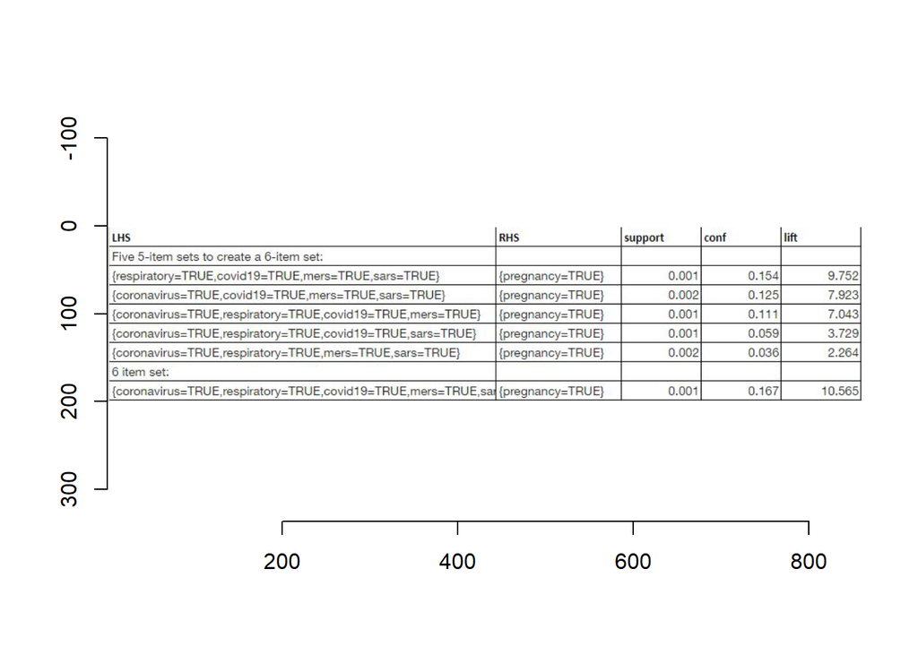

The first larger item set was a 6-item set including the words “respiratory”, “covid-19”, “coronavirus”, “sars”, “mers” and “pregnancy”. Obviously, the first 5 are constructed to be in the “left hand side”, while “pregnancy” was the supposed “effect” on the “right hand side”. This suggested that someone who is pregnant might be at greater risk in contracting or being severely affected by the coronavirus such as SARS, MERS or COVID19. Below is documentation of all five 5-item sets meeting minimum lift to create a 6-item set.

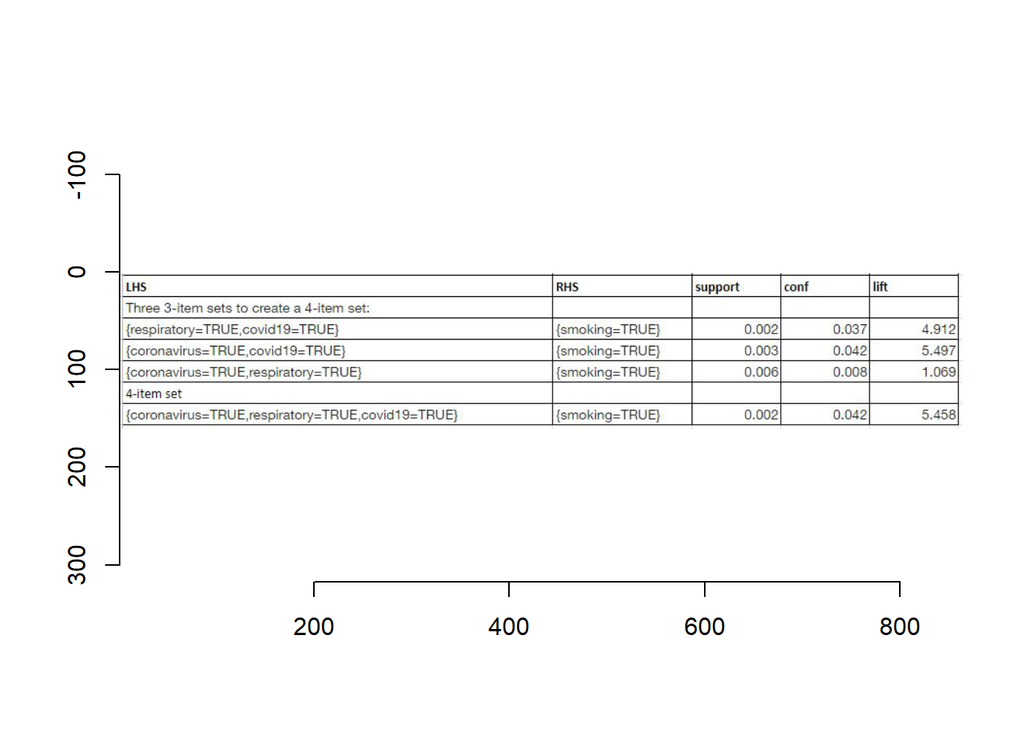

The second larger item set that was created involved “smoking” as the “right hand side” variable. By again creating rules that had a lift value greater than 1, a 4-item set rule was created showing the connection between “coronavirus”, “respiratory”, “covid-19” and “smoking”. It shows us that a person having weak respiratory is at higher risk of getting infected by coronavirus and COVID-19

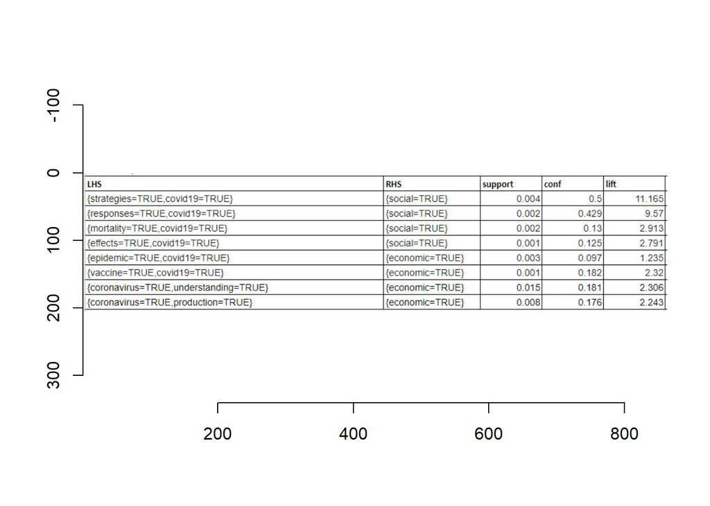

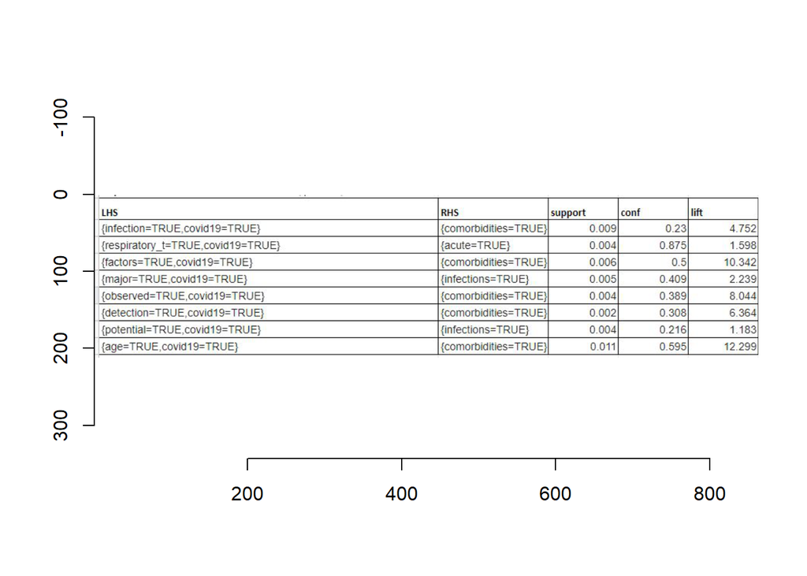

The table shows us that respiratory diseases and the presence of infections and comorbidities are related to COVID-19. It may imply that patients with these conditions may be at higher risks. But as COVID-19 is new, these rules are again accompanied by some key words such as “observed”, “detected”, “potential” which conveys the insufficient data and ambiguity in the research field regarding this.

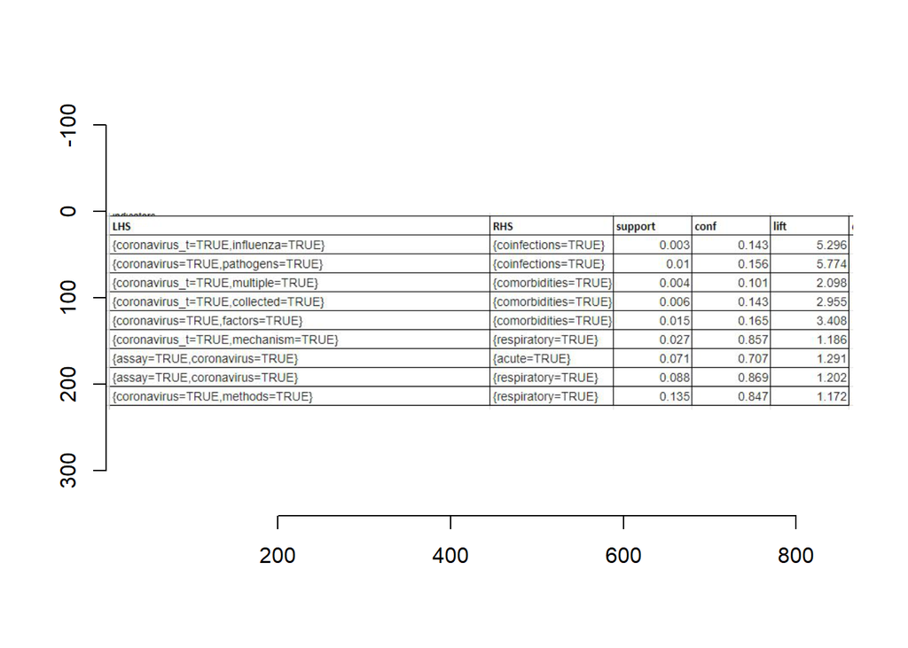

In above table, the key words in the LHS have words like pathogens, multiple, collected, factors, mechanism and assay which shows that we know more things about coronavirus than COVID-19; because these words are indicators that we know something for sure. But in the case of COVID-19, we don’t have those strong indicators.